# IS 4487 Lab 7

## Outline

Begin where you left on in Lab 6 with the *SuperStore Retail Orders* dataset. This lab will ask you to do a deeper data exploration

## Superstore Data Dictionary

ORDER VARIABLES:

- Order ID
- Order Date
- Order Year Month - Year and month of the order
- Order Type - Was the order completed at a store or online? (Retail, Online)
- Quantity - Quantity ordered for the product

CUSTOMER VARIABLES:

- Customer Name
- City
- State Province
- Email

PRODUCT VARIABLES:

- Product Name
- Product Line - Category of the product (i.e. Bikes Phones)
- Product Price - Price in US Dollars
- Product Status - Current status of the product (Active, Inactive)

## Load Libraries

➡️ Assignment Tasks

- Load any necessary libraries

```python
import pandas as pd
import numpy as np
import matplotlib.pyplot as plt
import seaborn as sns
```

```python
from google.colab import drive
drive.mount('/content/drive')
```

## Import Data into Dataframe

➡️ Assignment Tasks

- Import data from the SuperStore retail dataset into a dataframe (in GitHub go to Labs > DataSets)
- Describe or profile the dataframe

```python
df = pd.read_csv('https://github.com/Stan-Pugsley/is_4487_base/blob/main/Labs/DataSets/superstore_retail_orders.csv?raw=true')
```

## Prepare Data

➡️ Assignment Tasks

- Convert any numbers into the correct datatype if they are not already numeric
- Convert any character variables in to categories if they are appropriate for that datatype
- Check for outliers. Remove any outliers that appear to be mistakes
- Remove rows with empty (NULL) values
- Identify at least one variable with a missing value that can be imputed. Fill in those empty values.
- Add a "total_amount" variable based on the quantity and price

```python
#data preparation
df.info()
```

[output not shown]

```python
#converting order_date and order_year_month from string to datetime datatypes
df['order_date'] = pd.to_datetime(df['order_date'], format='%Y-%m-%d', errors='coerce')
df['order_year_month'] = pd.PeriodIndex(df['order_year_month'], freq='M')
#converting some objects into categories
df['product_line'] = df['product_line'].astype('category')
df['product_status'] = df['product_status'].astype('category')
df['order_type'] = df['order_type'].astype('category')
df['state_province'] = df['state_province'].astype('category')
#converting quantity to integer
df['quantity'] = pd.to_numeric(df['quantity'], errors='coerce').fillna(0).astype('int64')

print(df.info())
```

```
<class 'pandas.core.frame.DataFrame'>
RangeIndex: 56043 entries, 0 to 56042
Data columns (total 13 columns):
 #   Column            Non-Null Count  Dtype
---  ------            --------------  -----
 0   order_id          56043 non-null  int64
 1   order_date        55956 non-null  datetime64[ns]
 2   order_year_month  56011 non-null  period[M]
 3   customer_name     56043 non-null  object
 4   city              55569 non-null  object
 5   state_province    55569 non-null  category
 6   email             56043 non-null  object
 7   order_type        56043 non-null  category
 8   quantity          56043 non-null  int64
 9   product_name      56043 non-null  object
 10  product_line      56043 non-null  category
 11  product_price     56043 non-null  float64
 12  product_status    56043 non-null  category
dtypes: category(4), datetime64[ns](1), float64(1), int64(2), object(4), period[M](1)
memory usage: 4.1+ MB
None
```

```python
#using previous lab code to clean up outliers
df_clean = df.copy()

df_clean = df_clean[
    (df_clean['quantity'] <= 80) &
    (df_clean['product_price'] <= 6000) &
    (df_clean['order_date'].dt.year >= 2000) &
    (df_clean['order_date'].dt.year <= 2025)
]
print(df_clean.describe())
```

```
           order_id                     order_date      quantity  \
count  54473.000000                          54473  54473.000000
mean   61604.430984  2023-12-15 18:59:19.620362496      1.489343
min    45079.000000            2022-01-01 00:00:00      0.000000
25%    55608.000000            2023-10-05 00:00:00      1.000000
50%    61821.000000            2024-01-10 00:00:00      1.000000
75%    68019.000000            2024-04-10 00:00:00      2.000000
max    74146.000000            2024-06-30 00:00:00     20.000000
std     7502.794971                            NaN      0.616273

       product_price
count   54473.000000
mean      616.515416
min         2.290000
25%         7.950000
50%       475.600000
75%       914.620000
max      3578.270000
std       817.776413
```

```python
#checking for null data
print(df_clean.isnull().sum())
#imputing state_province data
#adding 'Unknown' to the category of 'state_province' and imputing null with 'Unknown'
df_clean['state_province'] = df_clean['state_province'].cat.add_categories(['Unknown'])
df_clean['state_province'] = df_clean['state_province'].fillna('Unknown')
#imputing null city data with 'Unknown'
df_clean['city'] = df_clean['city'].fillna('Unknown')
#verufying imputation
print(df_clean.isnull().sum())
```

```
order_id              0
order_date            0
order_year_month      0
customer_name         0
city                469
state_province      469
email                 0
order_type            0
quantity              0
product_name          0
product_line          0
product_price         0
product_status        0
dtype: int64
order_id            0
order_date          0
order_year_month    0
customer_name       0
city                0
state_province      0
email               0
order_type          0
quantity            0
product_name        0
product_line        0
product_price       0
product_status      0
dtype: int64
```

After imputation, no null values were found so I did not use .dropna() because it would be redundant.

```python
#total_amount variable creation
df_clean['total_amount'] = df_clean['product_price'] * df_clean['quantity']
```

## Prepare Data - Continued

➡️ Assignment Tasks

- Create a variable called "complete_customer_info". Use "1" for True and "2" for False. All customer fields must be valid and not empty before this variable is True.
- Create a bar chart showing the count of customers with complete informaiton versus incomplete information

```python
#created the 'complete_customer_info' variable
df_clean['complete_customer_info'] = 1  # Initialize all to True (1)

#identify rows with 'Unknown' in customer-related columns
unknown_customer_mask = df_clean[['customer_name', 'city', 'state_province', 'email']].map(lambda x: 'Unknown' in str(x)).any(axis=1)

#set 'complete_customer_info' to False (2) for those rows
df_clean.loc[unknown_customer_mask, 'complete_customer_info'] = 2
```

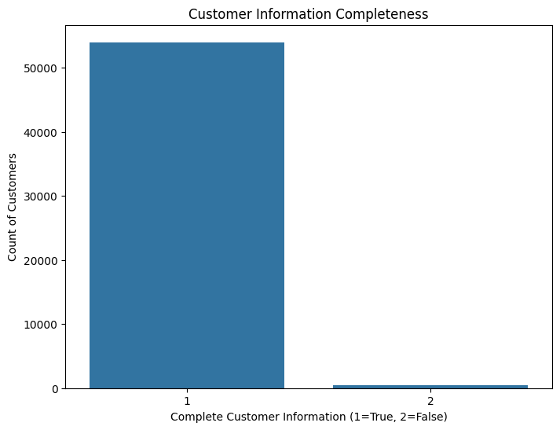

```python
#bar chart
plt.figure(figsize=(8, 6))
sns.countplot(x='complete_customer_info', data=df_clean)
plt.title('Customer Information Completeness')
plt.xlabel('Complete Customer Information (1=True, 2=False)')
plt.ylabel('Count of Customers')
plt.show()
```

## Prepare Data - Continued

➡️ Assignment Tasks

- Create seasonal buckets for Winter, Spring, Summer, Fall
- Create a chart to show revenue by season
- Create a chart to show revenue by year

```python
#seasonality
def get_season(month):
    if month in [12, 1, 2]:
        return 'Winter'
    elif month in [3, 4, 5]:
        return 'Spring'
    elif month in [6, 7, 8]:
        return 'Summer'
    else:
        return 'Fall'
#apply the function to create the 'season' column
df_clean['season'] = df_clean['order_date'].dt.month.apply(get_season)
```

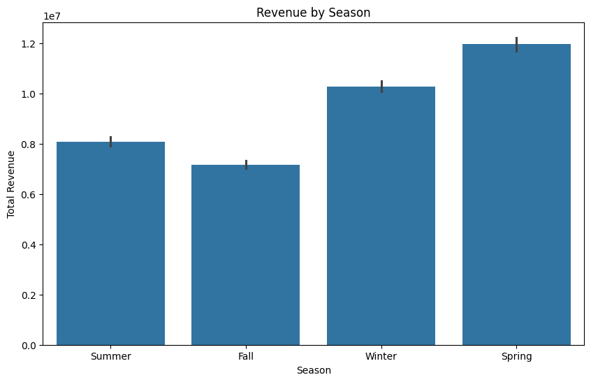

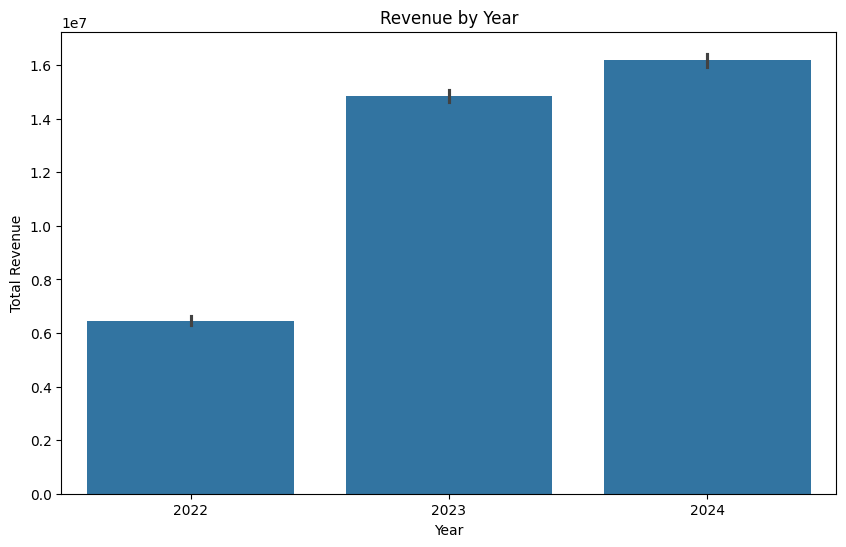

```python
#revenue over time
#chart to show revenue by season
plt.figure(figsize=(10, 6))
sns.barplot(x='season', y='total_amount', data=df_clean, estimator=sum)
plt.title('Revenue by Season')
plt.xlabel('Season')
plt.ylabel('Total Revenue')
plt.show()

#chart to show revenue by year
plt.figure(figsize=(10, 6))
sns.barplot(x=df_clean['order_date'].dt.year, y='total_amount', data=df_clean, estimator=sum)
plt.title('Revenue by Year')
plt.xlabel('Year')
plt.ylabel('Total Revenue')
plt.show()
```

## Prepare Data - Continued

➡️ Assignment Tasks

- Create a variable that will group product lines into "Outdoor" versus "Indoor" products.
- Create a plot to show the correlation between outdoor/indoor versus season

```python
#checking which categories could be considered outdoors
product_line_categories = df_clean['product_line'].unique()
product_line_categories
```

```
['Mobile', 'Bikes', 'Cameras', 'Electronics', 'Accessories', 'Clothing', 'Projector', 'Laptop', 'OfficeProducts']
Categories (9, object): ['Accessories', 'Bikes', 'Cameras', 'Clothing', ..., 'Laptop', 'Mobile',
                         'OfficeProducts', 'Projector']
```

```python
#indoor/outdoor variabledf_clean['product_category'] = 'Indoor'  # Default to Indoor
df_clean['product_category'] = 'Indoor'
df_clean.loc[df_clean['product_line'].isin(['Bikes']), 'product_category'] = 'Outdoor'
```

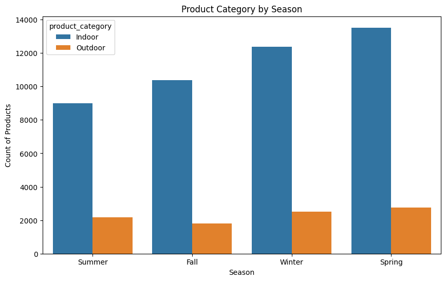

```python
#plot
plt.figure(figsize=(10, 6))
sns.countplot(x='season', hue='product_category', data=df_clean)
plt.title('Product Category by Season')
plt.xlabel('Season')
plt.ylabel('Count of Products')
plt.show()
```